# Relating Age, Brain and Cognition (ABC)

#### 2.2.4. Distinguishing ageing from practice effects

One problem with longitudinal cognitive testing is practice effects: people tend to get better at a test the more times they do it. Such practice effects are difficult to disentangle fully, but two ways to distinguish the effects of ageing from effects of practice are: 1) assume that practice effects do not change (eg attenuate) over time (lag), then jitter the lags (which works even if only 2 waves), or 2) assume practice effects asymptote after the first attempt, in which case having 3 waves, even if with fixed lag, is sufficient to separate them from linear age effects (capturing nonlinear age effects requires even more waves). Both these strategies decorrelate the regressor for practice effects from those for longitudinal ageing, as illustrated by uncommenting the relevant lines below:

```r
# Generate longitudinal effect
CS = matrix(0, nrow = 1, ncol = 2);
LG = matrix(0, nrow = 2, ncol = 2); LG[1,1] = -1; LG[2,1] = -1 # longitudinal decrease in B and C
rng_lag = c(1,10) # variable lag
#rng_lag = c(10,10) # fixed lag
dfl = long_data(rng_DoB, rng_bas, rng_lag, CS, LG, num_waves=2, noise_sd=2, npt=10000) # 2 waves (need jitter)
#dfl = long_data(rng_DoB, rng_bas, rng_lag, CS, LG, num_waves=3, noise_sd=2, npt=10000) # 3 waves (need to assume practice saturates after first attempt)

# Add single-time practice effect
dfl$prac <- 1*(dfl$wav>1)
dfl$C <- dfl$C + 10*dfl$prac

# Linear model from above (when fit to either 2 or 3 wave data from above)
m1 <- lmer('C ~ DoB + DoA + prac + (1|id)', data = dfl)
s <- summary(m1); s$call; s$coefficients
```

```
## lmer(formula = "C ~ DoB + DoA + prac + (1|id)", data = dfl)
```

```
##                  Estimate   Std. Error        df    t value   Pr(>|t|)
## (Intercept) -1.908174e+03 23.285125378 14270.487 -81.948197 0.00000000
## DoB          8.875897e-03  0.004751023  9996.236   1.868207 0.06176239
## DoA          9.954444e-01  0.010673925 10603.376  93.259451 0.00000000
## prac         1.002501e+01  0.065328048 10488.444 153.456433 0.00000000
```

The effect of DoA is significant despite the effect of prac (unless a fixed lag used with just 2 waves). Note that both models above also assume that the size of practice effects does not vary with age, which may not be correct (but could be modelled too).

Other ways to attempt to control for practice effects include saturating practice by doing the test many times before the first baseline assessment, or to estimate size of practice effects from an independent sample who do the test the same number of times, but with lags that are negligible in terms of ageing.

### 2.3. SEMs for longitudinal modelling

We now apply SEM to focus on longitudinal B<->C relationships. There are different types of SEM for such data, such as “Latent Curve Models” (LCM) and the more complex “Latent Change Score Models” (LCSM). Note that age (A) is typically not explicitly modelled in these, but implicit in the lags between measurements of B and C. Note also that the term “intercept” has a more precise meaning in SEM (a constant term reflecting the mean of a variable - see later), so we will use “baseline” to refer to the time-invariant property of an individual.

#### 2.3.1. Longitudinal mediation

Before we get into LCM and LCSM, we digress for a moment to revisit the mediation model in Section 1.2.5, to compare cross-sectional mediation with a longitudinal one based on change scores, i.e. difference between first and second measurements (e.g, `dA = A2-A1`):

```r
CS = matrix(0, nrow = 1, ncol = 2); CS[1] = -1; CS[2] = 1 # cross-sectional for A->B and B->C
LG = matrix(0, nrow = 2, ncol = 2) # no longitudinal dependencies
rng_lag = c(1,10)
dfl = long_data(rng_DoB, rng_bas, rng_lag, CS, LG, num_waves=2, noise_sd=5, npt=10000)

# Take baseline data only for cross-sectional model
#df4cs <- subset(dfl, dfl$wav==1)
#SEM4cs <- '
#    C ~ c1 * A
#    C ~ b1 * B; B ~ a1 * A
#    Mediation := a1*b1'
#SEM4cs_df4cs <- sem(SEM4cs, data=df4cs)
#p <- parameterEstimates(SEM4cs_df4cs); p[7,] # significant

# Same SEM structure but on difference scores between baseline and follow-up
df4lg <- data.frame(dA = dfl$A[dfl$wav==2]-dfl$A[dfl$wav==1],
                    dB = dfl$B[dfl$wav==2]-dfl$B[dfl$wav==1],
                    dC = dfl$C[dfl$wav==2]-dfl$C[dfl$wav==1])
SEM4lg <- '
    dC ~ c1 * dA
    dC ~ b1 * dB; dB ~ a1 * dA
    Mediation := a1*b1'
SEM4lg_df4lg <- sem(SEM4lg, data=df4lg)
p <- parameterEstimates(SEM4lg_df4lg); p[7,] # not significant
```

```
##         lhs op   rhs     label est se     z pvalue ci.lower ci.upper
## 7 Mediation := a1*b1 Mediation   0  0 0.407  0.684   -0.001    0.001
```

We can now see, correctly, that (changes in) B no longer significantly mediate the effect of (changes in) A on (changes in) C. This demonstrates how cross-sectional mediation results can differ from longitudinal ones: it may be (but not necessarily) that the original mediation by Brain of the effects of Age on Cognition was due to individual differences related to birth year (i.e., cohort effects), not true effects of ageing. Such cohort effects are “subtracted out” when calculating the change score for each participant.

#### 2.3.2. Latent Curve Models (Latent Growth Models)

To illustrate LCM (also called “Latent Growth Models”), we first generate data from 3 waves with both cross-sectional and longitudinal age-dependent effects. From this, we start by simply plotting B as a function of A:

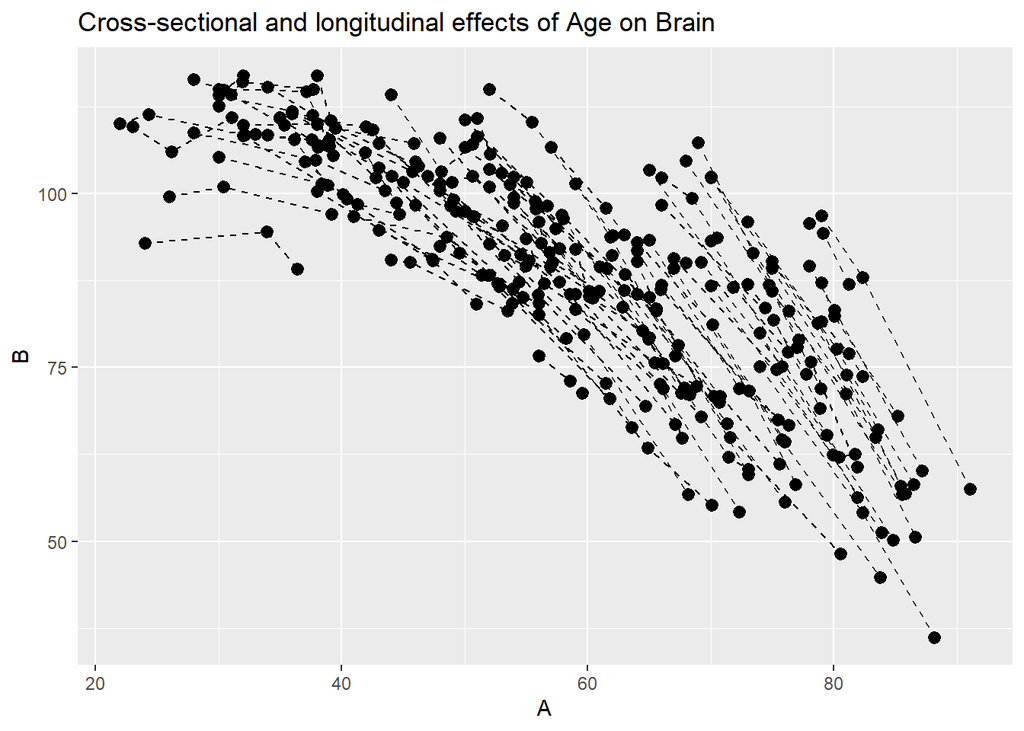

```r
set.seed(10)  # To render results reproducible
CS = matrix(0, nrow = 1, ncol = 2); CS[1] = -0.5; CS[2] = 0.5 # Cross-sectional differences in A->B and B->C
LG = matrix(0, nrow = 2, ncol = 2);
LG[1,1] = -0.1; LG[1,2] = -0.05 # Longitudinal A->B
LG[2,1] =  0.1; LG[2,2] =  0.05 # Longitudinal B->C
rng_lag = c(1,10)
dfl = long_data(rng_DoB, rng_bas, rng_lag, CS, LG, num_waves=3, noise_sd=2, npt=10000)
plot_long(dfl, xlab="A", ylab="B", titletxt = "Cross-sectional and longitudinal effects of Age on Brain")
```

In a LCM, we define two latent variables, one for the baseline (cross-sectional) and one for the slope (longitudinal). Unlike the SEM examples in Section 1, where latent variables captured multiple measures, here we define latent variables to capture the baseline and slope by using fixed weights: fixed at 1 for each wave to model the baseline, and incrementing 0, 1, 2 to model the linear slope (the initial value of 0 just means that the baseline corresponds to first timepoint). If the lags were not equally spaced, one could enter weights in actual years (eg 0, 2, 8), though the LCM does assume these lags are the same for all participants (or with more waves, one could add quadratic weights, etc).

(You may have noted that, when we generated the data, we specified a range of lags across participants. The reason for doing this was simply to get a larger range of brain change across participants; ie just a hack to avoid making the generative function above more complicated. In other words, we assume the lags were fixed in reality, and are just using a short-cut in the above function to generate larger variation across participants in their B values at each timepoint.)

##### 2.3.2.1 LCM for Brain change only

To fit an LCM to the Brain data, we use the “growth” sub-function of “lavaan”, which has an equivalent “sem” call, but avoids the need to specify some additional constraints (namely, specifying a structure for the means, fixing the observed intercepts to zero, but allowing the latent variable intercepts/means to be freely estimated, see https://lavaan.ugent.be/tutorial/growth.htm for more info). See Figure 5A for a graphical depiction.

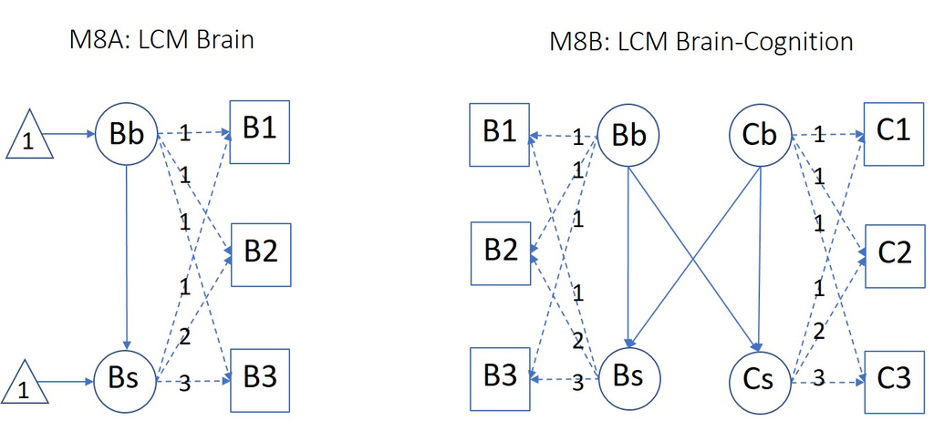

Figure 5. A: LCM for Brain change (dashed lines are fixed; self-connections not shown; intercepts in triangles). B: LCM for Brain-Cognition change (intercepts now not shown). b = baseline, s = slope.

To illustrate a trivial example, we first just estimate the baseline and slope for the B values across timepoints:

```r
B1 <- dfl$B[dfl$wav==1]
B2 <- dfl$B[dfl$wav==2]
B3 <- dfl$B[dfl$wav==3]
dfw = data.frame(B1, B2, B3)
SEM8_LCMB <- '
    bas =~ 1*B1 + 1*B2 + 1*B3
    slp =~ 0*B1 + 1*B2 + 2*B3
    slp ~ bas
#    # Define Factor Means
#    bas ~ 1; slp ~ 1
#    # Define Factor (Co)Variances
#    bas ~~ bas; slp ~~ slp
#    # Define Indicator Residual Variances
#    B1 ~~ B1; B2 ~~ B2; B3 ~~ B3
'
SEM8_LCMB_dfw <- lavaan::growth(SEM8_LCMB, data = dfw)
#SEM8_LCMB_dfw <- sem(SEM8_LCMB, data = dfw)
summary(SEM8_LCMB_dfw, header=FALSE, cov.std = FALSE)
```

```
##
## Parameter Estimates:
##
##   Standard errors                             Standard
##   Information                                 Expected
##   Information saturated (h1) model          Structured
##
## Latent Variables:
##                    Estimate  Std.Err  z-value  P(>|z|)
##   bas =~
##     B1                1.000
##     B2                1.000
##     B3                1.000
##   slp =~
##     B1                0.000
##     B2                1.000
##     B3                2.000
##
## Regressions:
##                    Estimate  Std.Err  z-value  P(>|z|)
##   slp ~
##     bas               0.297    0.008   39.203    0.000
##
## Intercepts:
##                    Estimate  Std.Err  z-value  P(>|z|)
##     bas              99.952    0.120  833.732    0.000
##    .slp             -39.160    0.760  -51.511    0.000
##
## Variances:
##                    Estimate  Std.Err  z-value  P(>|z|)
##    .B1                3.286    1.022    3.214    0.001
##    .B2               14.647    0.721   20.302    0.000
##    .B3               10.679    1.837    5.813    0.000
##     bas             140.587    2.235   62.899    0.000
##    .slp              23.846    1.141   20.891    0.000
```

```r
#summary(SEM8_LCMB_dfw, fit.measures=TRUE)
# Uncomment below to produce graphs of SEM fits, but they do not "knit" in Rmd, hence graphics imported
##graph_sem(model = SEM8_LCMB_dfw)
#semPlot::semPaths(SEM8_LCMB_dfw, what = "paths", whatLabels = "est", intercepts = TRUE, edge.color = "black")
```

Note that we explicitly test whether the slope depends on the baseline in a final regression term, which it does here, because we generated data in which the rate of decline in the brain increases with age (with LG[1,2]<0) *(or we could just examine the covariance between these latent variables, for which Z value similar but not identical - any reason for using covariances vs regression? regression better because implied directionality?*)

Note that in proper data analyses, one should always check overall model fit (by setting fit.measures=TRUE in the summary command; convention suggests good fits have CFI/TLI $> 0.95$, RMSEA $< 0.05$, and SRMR $< 0.08$). This linear slope model does not fit particularly well, in contrast to the LCSM model in next section, which can capture the quadratic-like effects of lag (from the way these data were generated).

##### 2.3.2.1 LCM for Brain-Cognition change

We can now add cognition to test for slope-slope relationships and baseline-slope relationships. Note that we now have positive dependencies of cognition on brain (even though brain is decreasing with age), where high brain values also mean higher rates of change (slopes) in cognition:

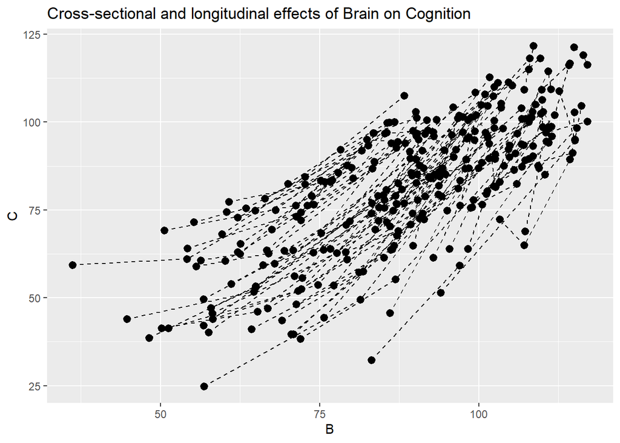

```r
plot_long(dfl, xlab="B", ylab="C", titletxt = "Cross-sectional and longitudinal effects of Brain on Cognition")
```

Having defined slope and baseline for brain and cognition separately, we can now add relationships between the two slopes and the two baselines (see Figure 5B for a graphical depiction):

```r
B1 <- dfl$B[dfl$wav==1]
B2 <- dfl$B[dfl$wav==2]
B3 <- dfl$B[dfl$wav==3]
C1 <- dfl$C[dfl$wav==1]
C2 <- dfl$C[dfl$wav==2]
C3 <- dfl$C[dfl$wav==3]
dfw = data.frame(B1, B2, B3, C1, C2, C3)
SEM8_LCMBC <- '
    B_bas =~ 1*B1 + 1*B2 + 1*B3
    B_slp =~ 0*B1 + 1*B2 + 2*B3
    C_bas =~ 1*C1 + 1*C2 + 1*C3
    C_slp =~ 0*C1 + 1*C2 + 2*C3

#    C_bas ~ B_bas
#    C_slp ~ B_slp

    B_slp ~ B_bas
    C_slp ~ C_bas

    C_slp ~ B_bas
    B_slp ~ C_bas

    C_bas ~~ B_bas
    C_slp ~~ B_slp
'
SEM8_LCMBC_dfw <- lavaan::growth(SEM8_LCMBC, data = dfw)
# Uncomment below to produce graphs of SEM fits, but they do not "knit" in Rmd, hence graphics imported
##graph_sem(model = SEM8_LCMBC_dfw)
#semPlot::semPaths(SEM8_LCMBC_dfw, what = "paths", whatLabels = "est", intercepts = TRUE, edge.color = "black")
```

*uncommenting the C_bas-B_bas and C_slp-B_slp ~ regressions, instead of the ~~ covariance relationship, lead to estimation errors, so kept as covariance relationship(plus semplot better!!!)*

When we fit this model, we can see that the C slope depends on the B baseline, but not vice versa:

```r
summary(SEM8_LCMBC_dfw, header=FALSE, cov.std = FALSE)
```

```
##
## Parameter Estimates:
##
##   Standard errors                             Standard
##   Information                                 Expected
##   Information saturated (h1) model          Structured
##
## Latent Variables:
##                    Estimate  Std.Err  z-value  P(>|z|)
##   B_bas =~
##     B1                1.000
##     B2                1.000
##     B3                1.000
##   B_slp =~
##     B1                0.000
##     B2                1.000
##     B3                2.000
##   C_bas =~
##     C1                1.000
##     C2                1.000
##     C3                1.000
##   C_slp =~
##     C1                0.000
##     C2                1.000
##     C3                2.000
##
## Regressions:
##                    Estimate  Std.Err  z-value  P(>|z|)
##   B_slp ~
##     B_bas             0.315    0.010   30.297    0.000
##   C_slp ~
##     C_bas             0.076    0.018    4.335    0.000
##     B_bas            -0.027    0.012   -2.347    0.019
##   B_slp ~
##     C_bas            -0.002    0.010   -0.166    0.868
##
## Covariances:
##                    Estimate  Std.Err  z-value  P(>|z|)
##   B_bas ~~
##     C_bas            72.088    1.431   50.387    0.000
##  .B_slp ~~
##    .C_slp            32.850    0.538   61.005    0.000
##
## Intercepts:
##                    Estimate  Std.Err  z-value  P(>|z|)
##     B_bas           100.008    0.120  833.884    0.000
##    .B_slp           -40.776    0.621  -65.656    0.000
##     C_bas            99.788    0.103  968.412    0.000
##    .C_slp           -19.651    1.081  -18.183    0.000
##
## Variances:
##                    Estimate  Std.Err  z-value  P(>|z|)
##    .B1                6.139    0.834    7.361    0.000
##    .B2               13.010    0.568   22.905    0.000
##    .B3               14.377    1.382   10.400    0.000
##    .C1               10.447    1.267    8.248    0.000
##    .C2               45.621    0.953   47.896    0.000
##    .C3               33.724    1.927   17.505    0.000
##     B_bas           138.213    2.149   64.311    0.000
##    .B_slp            21.041    0.970   21.702    0.000
##     C_bas            96.213    1.892   50.857    0.000
##    .C_slp            52.381    1.199   43.689    0.000
```

This suggests that brain levels are driving cognitive change, as expected.

#### 2.2.3. Latent Change Score Models (LCSM)

Earlier, we defined new variables like `dB` as the difference across two successive measurements. In LCSMs, we treat these differences as latent variables.

##### 2.2.3.1 LCSM for Brain change only

To illustrate this, we will again begin with modelling just the three brain measures (B1-B3). The graph is shown in Figure 6A, where we define two difference scores across B1-B2 and B2-B3, while the lavaan code for such a LCSM is below (the comments in code below explain purpose of each line):

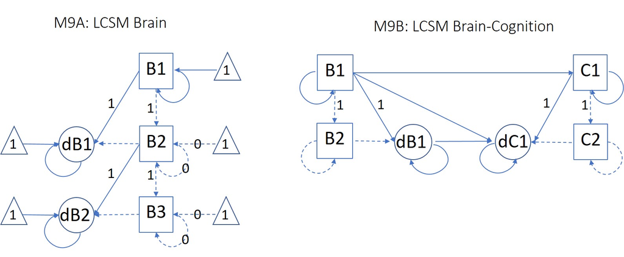

Figure 6. A: LCSM for Brain change (dashed lines are fixed; intercepts in triangles). B: LCSM for Brain-Cognition change (intercepts now not shown).

```r
SEM9_LCSMB <- '
# First change between B1 and B2
B2   ~ 1*B1          # This parameter regresses B2 perfectly on B1
dB1 =~ 1*B2          # Latent change score factor as measured perfectly by scores on B2
B2   ~ 0*1           # This constrains the intercept of B2 to 0
B2  ~~ 0*B2          # This fixes the variance of the B2 to 0

dB1  ~ 1             # This estimates the intercept of the change score
dB1  ~ B1            # This estimates how change depends on baseline
dB1 ~~ dB1           # This estimates the variance of the change score

# Second change between B2 and B3
B3   ~ 1*B2          # This parameter regresses B3 perfectly on B2
dB2 =~ 1*B3          # Latent change score factor as measured perfectly by scores on B3
B3   ~ 0*1           # This constrains the intercept of B3 to 0
B3  ~~ 0*B3          # This fixes the variance of the B3 to 0

dB2  ~ 1             # This estimates the intercept of the change score
dB2  ~ B2            # This estimates how change depends on baseline
dB2 ~~ dB2           # This estimates the variance of the change score

# Initial (baseline) values
B1   ~ 1             # This estimates the intercept of B1
B1  ~~ B1            # This estimates the variance of B1
'
SEM9_LCSMB_dfw <- lavaan(SEM9_LCSMB, data=dfw)
# Uncomment below to produce graphs of SEM fits, but they do not "knit" in Rmd, hence graphics imported
#semPlot::semPaths(SEM9_LCSMB_dfw, what = "paths", whatLabels = "est", intercepts = TRUE, edge.color = "black")
##graph_sem(model = SEM9_LCSMB_dfw)
```

The corresponding path model looks complicated, but it is essentially defining new latent variables dB1 and dB2 (“change scores”), about which we want to make inferences (along with the latent variable B1, and as a consequence, B2 and B3 are fixed). For example, while we could have just done a T-test to see if the slope dB1 is significantly different from 0, the power of this LCSM approach is that we can also infer 1) that its variance is significant (i.e., that individuals differ in their amount of change), and 2) that the amount of change depends on the initial, baseline value (e.g. the significant regression of dB1 on B1). See [Kievit et al. 2018](https://doi.org/10.1016/j.dcn.2017.11.007) for fuller explanation.

If you look at the results, including the overall model fit:

```r
summary(SEM9_LCSMB_dfw, header=FALSE, fit.measures = TRUE, cov.std = FALSE)
```

```
##
## Model Test Baseline Model:
##
##   Test statistic                             41521.389
##   Degrees of freedom                                 3
##   P-value                                        0.000
##
## User Model versus Baseline Model:
##
##   Comparative Fit Index (CFI)                    1.000
##   Tucker-Lewis Index (TLI)                       1.000
##
## Loglikelihood and Information Criteria:
##
##   Loglikelihood user model (H0)            -105429.919
##   Loglikelihood unrestricted model (H1)    -105427.850
##
##   Akaike (AIC)                              210875.839
##   Bayesian (BIC)                            210933.522
##   Sample-size adjusted Bayesian (SABIC)     210908.099
##
## Root Mean Square Error of Approximation:
##
##   RMSEA                                          0.018
##   90 Percent confidence interval - lower         0.003
##   90 Percent confidence interval - upper         0.037
##   P-value H_0: RMSEA <= 0.050                    0.998
##   P-value H_0: RMSEA >= 0.080                    0.000
##
## Standardized Root Mean Square Residual:
##
##   SRMR                                           0.001
##
## Parameter Estimates:
##
##   Standard errors                             Standard
##   Information                                 Expected
##   Information saturated (h1) model          Structured
##
## Latent Variables:
```

[output cut: 17 more lines]

```
## Intercepts:
##                    Estimate  Std.Err  z-value  P(>|z|)
##    .B2                0.000
##    .dB1             -35.570    0.553  -64.324    0.000
##    .B3                0.000
##    .dB2             -31.401    0.379  -82.771    0.000
##     B1               99.887    0.120  832.774    0.000
##
## Variances:
##                    Estimate  Std.Err  z-value  P(>|z|)
##    .B2                0.000
##    .dB1              43.465    0.615   70.711    0.000
##    .B3                0.000
##    .dB2              46.132    0.652   70.711    0.000
##     B1              143.868    2.035   70.711    0.000
```

```r
#summary(SEM9_LCSMB_dfw, fit.measures = TRUE, header=FALSE)
```

Note that the overall model fit is better than the LCM above. The reason for this is that the LCM assumes a single (linear) slope across the three timepoints, whereas the LCSM allows the slopes of each pairwise difference to differ. We can test the latter by constraining the slopes for dB1 and dB2 to be identical, and compare this “equated” model to the full model above. The Chi^2 test (and AIC, BIC) shows that the full model (where the slopes can differ) is better (because the data were generated such that the change depends on the current level):

```r
SEM9_LCSMB_eqtd <- '
# First change between B1 and B2
B2   ~ 1*B1          # This parameter regresses B2 perfectly on B1
dB1 =~ 1*B2          # Latent change score factor as measured perfectly by scores on B2
B2   ~ 0*1           # This constrains the intercept of B2 to 0
B2  ~~ 0*B2          # This fixes the variance of the B2 to 0

dB1  ~ a*1           # Intercept of the change score now constrained to match dB2 below
dB1  ~ B1            # This estimates how change depends on baseline
dB1 ~~ dB1           # This estimates the variance of the change score

# Second change between B2 and B3
B3   ~ 1*B2          # This parameter regresses B3 perfectly on B2
dB2 =~ 1*B3          # Latent change score factor as measured perfectly by scores on B3
B3   ~ 0*1           # This constrains the intercept of B3 to 0
B3  ~~ 0*B3          # This fixes the variance of the B3 to 0

dB2  ~ a*1           # Intercept of the change score now constrained to match dB1 above
dB2  ~ B2            # This estimates how change depends on baseline
dB2 ~~ dB2           # This estimates the variance of the change score

# Initial (baseline) values
B1   ~ 1             # This estimates the intercept of B1
B1  ~~ B1            # This estimates the variance of B1
'
SEM9_LCSMB_dfw_eqtd <- lavaan(SEM9_LCSMB_eqtd, data=dfw)
#summary(SEM9_LCSMB_dfw_eqtd, header=FALSE, fit.measures = FALSE, cov.std = FALSE)
anova(SEM9_LCSMB_dfw, SEM9_LCSMB_dfw_eqtd)
```

```
##
## Chi-Squared Difference Test
##
##                     Df    AIC    BIC   Chisq Chisq diff    RMSEA Df diff
## SEM9_LCSMB_dfw       1 210876 210934  4.1392
## SEM9_LCSMB_dfw_eqtd  2 210912 210963 42.7517     38.613 0.061329       1
##                     Pr(>Chisq)
## SEM9_LCSMB_dfw
## SEM9_LCSMB_dfw_eqtd  5.169e-10 ***
## ---
## Signif. codes:  0 '***' 0.001 '**' 0.01 '*' 0.05 '.' 0.1 ' ' 1
```

(a similar approach can be used to test whether the variance in the slopes dB1 and dB2 differ significantly across timepoints, etc).

##### 2.3.2.2. LCSM for Brain-Cognition change

Nonetheless, the real power of LCSM models in the current context comes when we have more than one longitudinal variable. Here we revert back to just two timepoints, to simplify the model structure. In the first model, we assume that cognitive baseline and change depends on brain baseline and change (last three lines in model definition below):

```r
SEM9_LCSMBC <- '
# Within-B changes
B2   ~ 1*B1          # This parameter regresses B2 perfectly on B1
dB1 =~ 1*B2          # Latent change score factor as measured perfectly by scores on B2
B2   ~ 0*1           # This constrains the intercept of B2 to 0
B2  ~~ 0*B2          # This fixes the variance of the B2 to 0

dB1  ~ 1             # This estimates the intercept of the change score
dB1  ~ B1            # This estimates how change depends on baseline
dB1 ~~ dB1           # This estimates the variance of the change score

B1   ~ 1             # This estimates the intercept of B1
B1  ~~ B1            # This estimates the variance of B1

# Within-C changes
C2   ~ 1*C1         # This parameter regresses C2 perfectly on C1
dC1 =~ 1*C2         # Latent change score factor as measured perfectly by scores on C2
C2   ~ 0*1          # This constrains the intercept of C2 to 0
C2  ~~ 0*C2         # This fixes the variance of the C2 to 0

dC1  ~ 1             # This estimates the intercept of the change score
dC1  ~ C1            # This estimates how change depends on baseline
dC1 ~~ dC1           # This estimates the variance of the change score

C1   ~ 1             # This estimates the intercept of C1
C1  ~~ C1            # This estimates the variance of B1

# Between B-C changes
C1  ~ B1             # Cognitive intercept depends on brain intercept
dC1 ~ dB1            # Cognition change depends on brain change
dC1 ~ B1             # Cognition change depends on baseline brain
'
SEM9_LCSMBC_dfw <- lavaan(SEM9_LCSMBC, data=dfw)
# Uncomment below to produce graphs of SEM fits, but they do not "knit" in Rmd, hence graphics imported
##graph_sem(model = SEM9_LCSMBC_dfw)
#semPlot::semPaths(SEM9_LCSMBC_dfw, what = "paths", whatLabels = "est", intercepts = TRUE, edge.color = "black")
```

The between-domain brain-cognition relationships include 1) dependency of C baseline on B baseline (cross-sectional), 2) dependency of C slope on B slope (change-change longitudinal) and 3) dependency of C slope on B baseline (“lead-lag” dependency) - see Figure 6B. If we examine the coefficients:

```r
summary(SEM9_LCSMBC_dfw, header=FALSE, cov.std = FALSE, fit.measures = TRUE)
```

```
##
## Model Test Baseline Model:
##
##   Test statistic                             39428.362
##   Degrees of freedom                                 6
##   P-value                                        0.000
##
## User Model versus Baseline Model:
##
##   Comparative Fit Index (CFI)                    1.000
##   Tucker-Lewis Index (TLI)                       0.998
##
## Loglikelihood and Information Criteria:
##
##   Loglikelihood user model (H0)            -140911.152
##   Loglikelihood unrestricted model (H1)    -140902.951
##
##   Akaike (AIC)                              281848.304
##   Bayesian (BIC)                            281942.038
##   Sample-size adjusted Bayesian (SABIC)     281900.726
##
## Root Mean Square Error of Approximation:
##
##   RMSEA                                          0.039
##   90 Percent confidence interval - lower         0.024
##   90 Percent confidence interval - upper         0.057
##   P-value H_0: RMSEA <= 0.050                    0.829
##   P-value H_0: RMSEA >= 0.080                    0.000
##
## Standardized Root Mean Square Residual:
##
##   SRMR                                           0.009
##
## Parameter Estimates:
##
##   Standard errors                             Standard
##   Information                                 Expected
##   Information saturated (h1) model          Structured
##
## Latent Variables:
```

[output cut: 24 more lines]

```
##    .B2                0.000
##    .dB1             -35.570    0.553  -64.324    0.000
##     B1               99.887    0.120  832.774    0.000
##    .C2                0.000
##    .dC1              22.236    0.799   27.835    0.000
##    .C1               51.757    0.703   73.595    0.000
##
## Variances:
##                    Estimate  Std.Err  z-value  P(>|z|)
##    .B2                0.000
##    .dB1              43.465    0.615   70.711    0.000
##     B1              143.868    2.035   70.711    0.000
##    .C2                0.000
##    .dC1              46.390    0.656   70.711    0.000
##    .C1               70.301    0.994   70.711    0.000
```

we find positive baseline-baseline and slope-slope dependency, though a negative slope-baseline dependency. *why is this - shouldn’t slope-baseline be positive too - eg in plot above, larger cognitive changes for higher values of B???*

*also, if add dB1 ~ C1, then model fit even better, and the dB1 ~ C1 is significant (albeit small), even though shouldn’t be??*

We can then compare this model to a “reversed” model, where cognitive baseline and slope drive brain baseline and slope instead. This is certainly plausible in real life (e.g, cognitive ability might influence lifestyle choices that affect the brain health), but we know this was not how the data were created in these simulations, so we expect the reversed model to fit worse:

```r
SEM9_LCSMBC_rev <- '
# Within-B changes
B2   ~ 1*B1          # This parameter regresses B2 perfectly on B1
dB1 =~ 1*B2          # Latent change score factor as measured perfectly by scores on B2
B2   ~ 0*1           # This constrains the intercept of B2 to 0
B2  ~~ 0*B2          # This fixes the variance of the B2 to 0

dB1  ~ 1             # This estimates the intercept of the change score
dB1  ~ B1            # This estimates how change depends on baseline
dB1 ~~ dB1           # This estimates the variance of the change score

B1   ~ 1             # This estimates the intercept of B1
B1  ~~ B1            # This estimates the variance of B1

# Within-C changes
C2   ~ 1*C1         # This parameter regresses C2 perfectly on C1
dC1 =~ 1*C2         # Latent change score factor as measured perfectly by scores on C2
C2   ~ 0*1          # This constrains the intercept of C2 to 0
C2  ~~ 0*C2         # This fixes the variance of the C2 to 0

dC1  ~ 1             # This estimates the intercept of the change score
dC1  ~ C1            # This estimates how change depends on baseline
dC1 ~~ dC1           # This estimates the variance of the change score

C1   ~ 1             # This estimates the intercept of C1
C1  ~~ C1            # This estimates the variance of B1

# Between B-C changes
B1  ~ C1             # Brain intercept depends on cognitive intercept
dB1 ~ dC1            # Brain change depends on cognitive change
dB1 ~ C1             # Brain change depends on baseline cognitive
'
SEM9_LCSMBC_dfw_rev <- lavaan(SEM9_LCSMBC_rev, data=dfw)
#summary(SEM9_LCSMBC_dfw_rev,  header=FALSE, cov.std = FALSE, fit.measures = TRUE)
anova(SEM9_LCSMBC_dfw, SEM9_LCSMBC_dfw_rev)
```

```
##
## Chi-Squared Difference Test
##
##                     Df    AIC    BIC   Chisq Chisq diff RMSEA Df diff
## SEM9_LCSMBC_dfw      1 281848 281942  16.401
## SEM9_LCSMBC_dfw_rev  1 282131 282225 299.137     282.74     0       0
##                     Pr(>Chisq)
## SEM9_LCSMBC_dfw
## SEM9_LCSMBC_dfw_rev
```

which it does, i.e, “rev” model has higher AIC/BIC and Chisq error. This provides evidence for the causal direction being from brain to cognition rather than vice versa.

### 2.4. Summary of longitudinal SEMs

Note we have only considered a single measure of each variable at each timepoint, but it is easy to extend LCSMs like above to include latent factors (e.g, of Brain and Cognition) that are estimated from multiple measurements at each timepoint (and be able to test for measurement invariance, as Section 1 above, but now across time within an individual, rather than across individuals in different age groups).

More generally, returning to the question of ways to model effects of Age, note that we no longer need to explicitly include Age in the model, since the effect of Age(ing) is captured by the change in those variables. (We could add Age as an input into the baseline brain variable (B1) but this would not affect the type of conclusions above about effects of Brain on Cognition - it is sufficient that the changes in Brain (which we happen to know are due to ageing) that drive the changes in cognition.)

This concludes our primer for now. We hope it has illustrated some of the main concepts in the cognitive neuroscience of ageing, though of course there are many more types of models, and much more comprehensive textbooks that work instead from first principles. Feedback/corrections/comments welcomed.